# STA207 Final Project

# 6 Sensitive Analysis:

```r
summary(df.new$wholesale_price - fit.scale.new$fitted.values)
```

```
##    Min. 1st Qu.  Median    Mean 3rd Qu.    Max.
## -46.745 -19.285   1.707   0.000  17.407  43.851
```

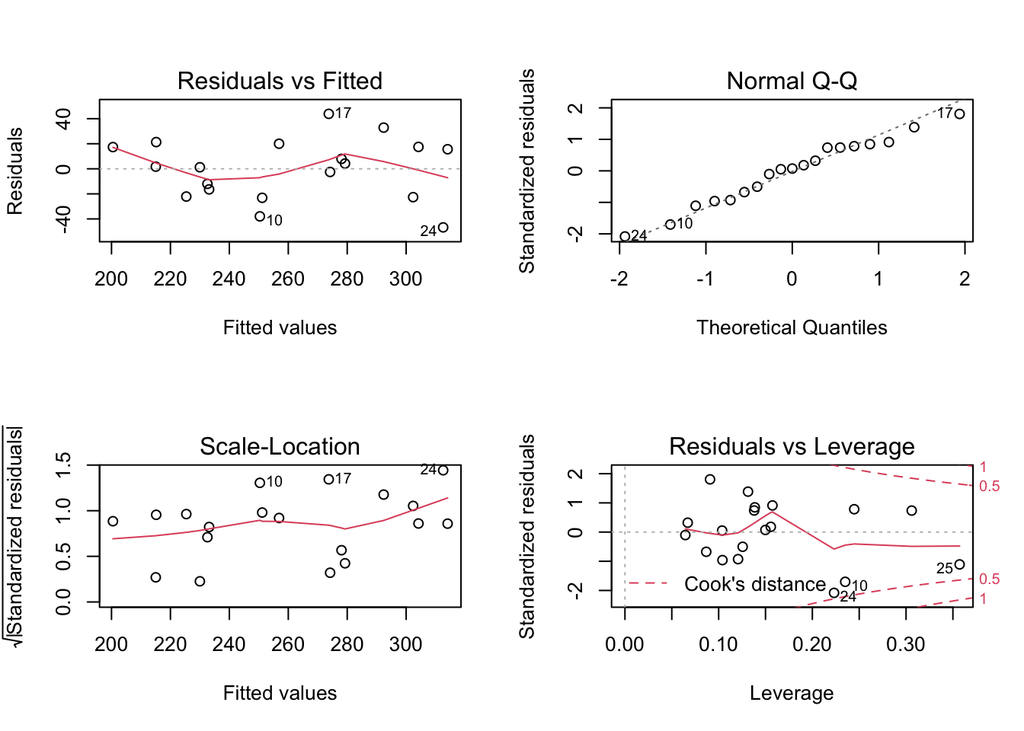

```r
par(mfrow = c(2,2))
plot(fit.scale.new)
```

The median value of residuals is centered around 0, this would tell us our residuals were somewhat symmetrical and that our model was predicting kind of evenly. In the quantile-quantile plot(Normal Q-Q plot), all the points are roughly going along with the dot line. Overall the residuals look to have a fairly normal distribution from Q-Q plot. From Residuals vs Fitted plot and scale-location plot, we can see that this model does not a prefect model for our data. I think the reason is that we only have 19 observation, the model could be as accurate as we want. In conclusion, this fitted model still be a moderate model to help us explaining the changes in dependent variable - `beef wholesale price`.

Causal Inference: From the data I had, it seems like we have a chance to conduct causal inference analysis, because I have the wholesale price data before and after COVID-19. However, I cannot separate the dataa into treatment group and control group. When COVID-19 happened, everyone and everything in this world are forced to face this pandemic, nothing could be excluded. The causal inference without treatment group and control group are not rigorous, so I cannot conduct statistical causal inference. In the following, I will shows the price trend before COVID-19 and after COVID-19.

```r
whole_sale_before <- whole_sale[whole_sale$Period > "2017-12-01" & whole_sale$Period < "2020-01-01",]
colnames(whole_sale_before) <- c("date", "wholesale_price", "increasing")
whole_sale_before$date <- as.Date(whole_sale_before$date)
whole_sale_before$wholesale_price <- as.double(whole_sale_before$wholesale_price)
```

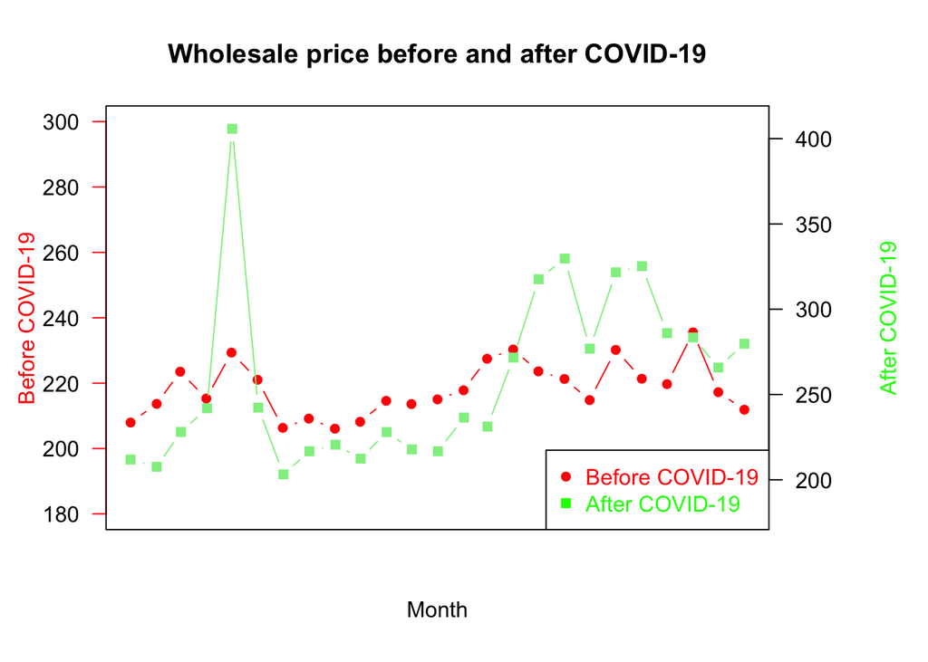

```r
par(mar=c(5, 4, 4, 6))
## Plot cumulative cases data and draw its axis
plot(whole_sale_before$date, whole_sale_before$wholesale_price, axes=FALSE, ylim=c(180,300), xlab="", ylab="",pch = 16, type="b",col="red", main="Wholesale price before and after COVID-19")
axis(2, ylim=c(180,300),col="red",las=1)  ## las=1 makes horizontal labels
mtext("Before COVID-19",col = 'red',side=2,line=2.5)
box()
par(new=TRUE)

## Plot the cumulative deaths data and put axis scale on right
plot(whole_sale_after$date, whole_sale_after$wholesale_price, xlab="", ylab="",pch = 15, ylim=c(180,410),
     axes=FALSE, type="b", col="lightgreen")
## a little farther out (line=4) to make room for labels
mtext("After COVID-19",side=4,col="green",line=4)
axis(4, ylim=c(180,410), col="black",col.axis="black",las=1)

## Draw the time axis
mtext("Month",side=1,col="black",line=2.5)

## Add Legend
legend("bottomright",legend=c("Before COVID-19","After COVID-19"),
  text.col=c("red","green"),pch=c(16,15),col=c("red","green"))
```

From the plot above, price trend before and after COVID-19 roughly share the similar trend. However, April 2020 - July 2020 shows very abnormal pattern. Taking into account the epidemic, April 2020 is the start point of COVID-19 breakout in the United States, which align with the abnormal pattern.

# 7 Discussion

# 8 Acknowledgement

None

# 9 Code

```r
knitr::opts_chunk$set(echo = TRUE)
library(tidyverse, quietly = T)
library(gplots, quietly = T)
library("readxl", quietly = T)
covid <- read_csv("https://covid19.who.int/WHO-COVID-19-global-data.csv", show_col_types = FALSE)
covid <- covid %>%filter(WHO_region != "Other") %>%
mutate(WHO_region = fct_recode(WHO_region,"Eastern Mediterranean"="EMRO","Europe" = "EURO","Africa" = "AFRO", "Western Pacific" = "WPRO","Americas"="AMRO","South-East Asia" = "SEARO"))

covid_region <- covid %>% dplyr::select(Date_reported,WHO_region,New_cases,Cumulative_cases,New_deaths,Cumulative_deaths) %>% group_by(Date_reported, WHO_region) %>% summarise_each(funs(sum))
ggplot(covid_region, aes(x = Date_reported, y = New_cases)) +
  geom_line(aes(color = WHO_region))+
  scale_x_continuous(breaks = pretty(covid_region$Date_reported, n = 12)) +
  guides(color="none") +
  labs(x = "Date reported", y = "New cases",color='WHO region')

ggplot(covid_region, aes(x = Date_reported, y = Cumulative_cases)) +
  geom_line(aes(color = WHO_region)) +
  scale_x_continuous(breaks = pretty(covid_region$Date_reported, n = 12)) +
  guides(color="none") +
  labs(x = "Date reported", y = "New deaths",color='WHO region')
max_date <- max(covid$Date_reported)
covid_max_date <- covid[covid$Date_reported == max_date,]
covid_max_date_AMRO <- covid_max_date[covid_max_date$WHO_region == "Americas",]
covid_max_date_AMRO <- covid_max_date_AMRO[,c(2,6)]
covid_max_date_AMRO$Cumulative_cases <- as.double(covid_max_date_AMRO$Cumulative_cases)
barplot(covid_max_date_AMRO$Cumulative_cases,names.arg = covid_max_date_AMRO$Country_code, las = 2, cex.name=0.5, xlab="Country Code",ylab="Cumulative Cases",col="blue", main="Cumulative cases in Americas")
meat.consumption <- read.csv(file = 'per-capita-meat-type.csv')
meat.consumption <- meat.consumption[meat.consumption$Year == 2017,][, c(2,4)]
colnames(meat.consumption) <- c("Country_code", "Beef_consumption")
meat.consumption <- meat.consumption[order(-meat.consumption$Beef_consumption),][1:10,]
barplot(meat.consumption$Beef_consumption,names.arg = meat.consumption$Country_code, las = 2, xlab="Country Code",ylab="Beef Consumption",col="mediumpurple", main="Top beef consumption country bar plot")
covid_US <- covid[covid$Country == "United States of America",]
covid_US <- covid_US[, c(1,5,6,7,8)]

par(mar=c(5, 4, 4, 6) + 0.1)
## Plot cumulative cases data and draw its axis
plot(covid_US$Date_reported, covid_US$Cumulative_cases, axes=FALSE, ylim=c(0,8e+07), xlab="", ylab="", type="l",col="red", main="Cumulative cases and deaths data")
axis(2, ylim=c(0,6e+08),col="red",las=1)  ## las=1 makes horizontal labels
mtext("cumulative cases",side=2,line=2.5)
box()
par(new=TRUE)

## Plot the cumulative deaths data and put axis scale on right
plot(covid_US$Date_reported, covid_US$Cumulative_deaths, xlab="", ylab="", ylim=c(0,1e+06),
    axes=FALSE, type="l", col="lightgreen")
## a little farther out (line=4) to make room for labels
mtext("cumulative deaths",side=4,col="black",line=4)
axis(4, ylim=c(0,1e+06), col="black",col.axis="black",las=1)

## Draw the time axis
mtext("Date",side=1,col="black",line=2.5)

## Add Legend
legend("topleft",legend=c("Cumulative Cases","Cumulative Deaths"),
  text.col=c("red","lightgreen"),pch=c(16,15),col=c("red","lightgreen"))
par(mar=c(5, 4, 4, 6) + 0.1)

plot(covid_US$Date_reported, covid_US$New_cases, axes=FALSE, ylim=c(0,1.5e+06), xlab="", ylab="", type="l",col="blue", main="New cases and deaths data")
axis(2, ylim=c(0,1.5e+06),col="blue",las=1)
mtext("new cases",side=2,line=2.5)
box()
par(new=TRUE)

plot(covid_US$Date_reported, covid_US$New_deaths, xlab="", ylab="", ylim=c(0,4000),
    axes=FALSE, type="l", col="yellow")

mtext("new deaths",side=4,col="black",line=4)
axis(4, ylim=c(0,4000), col="black",col.axis="black",las=1)

mtext("Date",side=1,col="black",line=2.5)

legend("topleft",legend=c("New Cases","New Deaths"),
  text.col=c("blue","yellow"),pch=c(16,15),col=c("blue","yellow"))
Wholesale <- read_excel("WholesalePrices.xlsx", sheet = "Historical", skip = 3)
Wholesale <- Wholesale[,c(1,2)]
colnames(Wholesale) <- c("Period", "wholesale_price")
# In the following, I combined data from current sheet with data from historical sheet. By manually checking, I added January 2022 live cattle price to my live stock price data.
Jan_data <- data.frame(as.Date("2022-01-01"), 279.75)
names(Jan_data) <- c("Period", "wholesale_price")
whole_sale <- rbind(Wholesale, Jan_data)
Livestock <- read_excel("LivestockPrices.xlsx", sheet = "Historical", skip = 3)
Livestock <- Livestock[,1:8]
colnames(Livestock) <- c("date", "price1","price2","price3","price4","price5","price6","price7")

Livestock$price1 <- as.double(Livestock$price1)
Livestock$price2 <- as.double(Livestock$price2)
Livestock$price3 <- as.double(Livestock$price3)
Livestock$price4 <- as.double(Livestock$price4)
Livestock$price5 <- as.double(Livestock$price5)
Livestock$price6 <- as.double(Livestock$price6)
Livestock$price7 <- as.double(Livestock$price7)

Livestock$cattle_price <- rowMeans(Livestock[,2:8], na.rm = T)
Livestock <- Livestock[,c(1,9)]
# In the following, I combined data from current sheet with data from historical sheet. By manually checking, I added January 2022 live cattle price to my live stock price data.
Jan<- c(136.75,196.00,173.75,158.25,168.50,148.75)
Jan<- mean(Jan)
Jan_data <- data.frame(as.Date("2022-01-01"), Jan)
names(Jan_data) <- c("date", "cattle_price")
Live_stock <- rbind(Livestock, Jan_data)
Live_stock <- Live_stock[Live_stock$date > "2019-12-01",]
govern <- read.csv(file = "covid-stringency-index.csv")
govern <-govern[govern$Code == "USA",]
govern <- govern[,3:4]
# Since my the price data is monthly collect, I will also monthly select stringency_index data.
govern <- dplyr::filter(govern, grepl("01-01|02-01|03-01|04-01|05-01|06-01|07-01|08-01|09-01|10-01|11-01|12-01", Day))
# 2020-01-01 data is missing, since 2020-02-01's stringency_index is 0, we can simply fill this month's stringency_index with 0.
J <- data.frame("2020-01-01", 0.00)
names(J) <- c("Day", "stringency_index")
govern <- rbind(J, govern)
# Also since we only have price data till the Jan 2022, we will not include Feb 2022 data.
govern <- govern[1:25,]
colnames(govern) <- c("date", "stringency_index")
govern$date <- as.Date(govern$date)
# We will only using New Case Variable to represent the COVID-19 situation
covid_US_NC <- covid_US[, c(1,2)]
#Since the beef price data is monthly, we will also apply monthly date on COVID case data.
covid_US_NC[,1] <- substr(covid_US_NC$Date_reported, 1, 7)
covid_US_NC <- aggregate(New_cases~Date_reported,data=covid_US_NC,sum)
#Create cum sum
covid_US_NC$New_cases <- cumsum(covid_US_NC$New_cases)
covid_US_NC$Date_reported <- as.Date(paste(covid_US_NC$Date_reported, "-01", sep = ""))
plot(covid_US_NC$New_cases~covid_US_NC$Date_reported, type = "l", col = 'lightblue', lwd = 3, ylab = "New Cases", xlab = "Date", main = "New cases line plot")
covid_US_NC <- covid_US_NC[covid_US_NC$Date_reported < "2022-02-01",]
colnames(covid_US_NC) <- c("date", "New_cases")
```

```r
whole_sale_after <- whole_sale[whole_sale$Period > "2019-12-01", ]
plot(whole_sale_after$wholesale_price~ whole_sale_after$Period, type = "l", xlab = 'Period', ylab = 'monthly wholesale price', col = 'mediumpurple2', main  = "The trend of wholesale beef price")
colnames(whole_sale_after) <- c("date", "wholesale_price")
whole_sale_after$date <- as.Date(whole_sale_after$date, format="%Y-/%m-/%d")
whole_sale_after$wholesale_price <- as.double(whole_sale_after$wholesale_price)
ws <- merge(covid_US_NC, whole_sale_after[,c(1,2)],by="date")
summary(ws[,2:3])
cor(ws[, 2:3])
par(mar=c(5, 4, 4, 6) + 0.1)
plot(ws$date, ws$New_cases, pch=16, axes=FALSE, ylim=c(0,6e+07), xlab="", ylab="", type="b",col="red", main="Wholesale and Covid data")
axis(2, ylim=c(0,6e+07),col="red",las=1)
mtext("New Cases",side=2,line=2.5)
box()
par(new=TRUE)

plot(ws$date, ws$wholesale_price, pch=15,  xlab="", ylab="", ylim=c(195,410),
    axes=FALSE, type="b", col="lightgreen")

mtext("Price Trend",side=4,col="black",line=4)
axis(4, ylim=c(195,410), col="black",col.axis="black",las=1)

mtext("Date",side=1,col="black",line=2.5)

legend("bottomright",legend=c("New Cases","Price Trend"),
  text.col=c("red","lightgreen"),pch=c(16,15),col=c("red","lightgreen"))
Live_stock$date <- as.Date(Live_stock$date)
data <- merge(ws, Live_stock,by="date")
data.new <- merge(data, govern,by="date")
#Now we have cleaned data, we could eliminate date variable from the data frame
df <- data.new[,2:5]
df <- df[,c(2,3,4,1)]
#summary statistics
summary(df)
#scatter plot matrix with lower panel correlation
panel.cor <- function(x, y, digits = 2, prefix = "", cex.cor, ...) {
  usr <- par("usr")
  on.exit(par(usr))
  par(usr = c(0, 1, 0, 1))
  r <- abs(cor(x, y, use = "complete.obs"))
  txt <- format(c(r, 0.123456789), digits = digits)[1]
  txt <- paste(prefix, txt, sep = "")
  if (missing(cex.cor)) cex.cor <- 0.8/strwidth(txt)
  text(0.5, 0.5, txt, cex =  cex.cor * (1 + r) / 2)
}


pairs(df,  col = 'steelblue', cex = 1, panel = panel.smooth, lower.panel = panel.cor, main = "scatter plot and correlation")
par(mfrow = c(2,2))
for (i in 1:4) {
  plot(df[,i], main = paste('Line plot of', colnames(df[i]), sep = ' '), xlab = colnames(df[i]), col = 'steelblue', type = "l", pwd = 3)
}
lm.fit <- lm(wholesale_price~cattle_price + stringency_index + New_cases, data = df)
summary(lm.fit)
par(mar=c(5, 4, 4, 6))
## Plot cumulative cases data and draw its axis
plot(df$wholesale_price, axes=FALSE, ylim=c(195,410), xlab="", ylab="",pch = 16, type="b",col="red", main="Wholesale price and live stock price during COVID-19")
axis(2, ylim=c(195,410),col="red",las=1)  ## las=1 makes horizontal labels
mtext("Wholesale price",col = 'red',side=2,line=2.5)
box()
par(new=TRUE)

plot(df$cattle_price, xlab="", ylab="",pch = 15, ylim=c(125,170), axes=FALSE, type="b", col="lightgreen")

mtext("Livestock Price",side=4,col="lightgreen",line=4)
axis(4, ylim=c(125,170), col="black",col.axis="black",las=1)

## Draw the time axis
mtext("Month",side=1,col="black",line=2.5)

## Add Legend
legend("bottomright",legend=c("Wholesale price","Live Stock Price"),
  text.col=c("red","lightgreen"),pch=c(16,15),col=c("red","lightgreen"))
df.new <- data.new[data.new$date > "2020-06-01",2:5]
df.new <- df.new[,c(2,3,4,1)]
lm.fit.new <- lm(wholesale_price~cattle_price + stringency_index + New_cases, data = df.new)
summary(lm.fit.new)
df.scale <- df.new
df.scale[,2:4] <- scale(df.scale[,2:4])
fit.scale <- lm(wholesale_price~cattle_price + stringency_index + New_cases, data = df.scale)
summary(fit.scale)
anova(fit.scale)
fit.scale.new <- lm(wholesale_price~cattle_price + stringency_index, data = df.new)
car::vif(fit.scale.new)
summary(fit.scale.new)
summary(df.new$wholesale_price - fit.scale.new$fitted.values)
par(mfrow = c(2,2))
plot(fit.scale.new)
whole_sale_before <- whole_sale[whole_sale$Period > "2017-12-01" & whole_sale$Period < "2020-01-01",]
colnames(whole_sale_before) <- c("date", "wholesale_price", "increasing")
whole_sale_before$date <- as.Date(whole_sale_before$date)
whole_sale_before$wholesale_price <- as.double(whole_sale_before$wholesale_price)
par(mar=c(5, 4, 4, 6))
## Plot cumulative cases data and draw its axis
plot(whole_sale_before$date, whole_sale_before$wholesale_price, axes=FALSE, ylim=c(180,300), xlab="", ylab="",pch = 16, type="b",col="red", main="Wholesale price before and after COVID-19")
axis(2, ylim=c(180,300),col="red",las=1)  ## las=1 makes horizontal labels
mtext("Before COVID-19",col = 'red',side=2,line=2.5)
box()
par(new=TRUE)

## Plot the cumulative deaths data and put axis scale on right
plot(whole_sale_after$date, whole_sale_after$wholesale_price, xlab="", ylab="",pch = 15, ylim=c(180,410),
     axes=FALSE, type="b", col="lightgreen")
## a little farther out (line=4) to make room for labels
mtext("After COVID-19",side=4,col="green",line=4)
axis(4, ylim=c(180,410), col="black",col.axis="black",las=1)

## Draw the time axis
mtext("Month",side=1,col="black",line=2.5)

## Add Legend
legend("bottomright",legend=c("Before COVID-19","After COVID-19"),
  text.col=c("red","green"),pch=c(16,15),col=c("red","green"))
```

# 10 Reference

World Health Organization. Who Coronavirus(COVID-19)[Data]. Retrieved from https://covid19.who.int/

U.S. DEPARTMENT OF AGRICULTURE Economic Research Service. Livestock and Meat Domestic Data[Data]. Retrieved from https://www.ers.usda.gov/data-products/livestock-and-meat-domestic-data/livestock-and-meat-domestic-data/#Wholesale%20Prices

U.S. DEPARTMENT OF AGRICULTURE Economic Research Service. Wholesale and Meat Domestic Data[Data]. Retrieved from https://www.ers.usda.gov/data-products/livestock-and-meat-domestic-data/livestock-and-meat-domestic-data/#Wholesale%20Prices

Our World in Data. Policy Responses to the Coronavirus Pandemic. Government Stringency Index[Data]. Retrieved from https://ourworldindata.org/covid-stringency-index

Our World in Data. Per capita meat consumption by type, 2020[Data]. Retrived from https://ourworldindata.org/grapher/per-capita-meat-type?country=CHN~USA~IND~ARG~PRT~ETH~JPN~GBR~BRA